# Understanding Model Complexity and Overfitting

## Import Libraries

```python
import scipy.io
import numpy as np
import cv2
import matplotlib.pyplot as plt
from sklearn.model_selection import train_test_split
from sklearn.tree import DecisionTreeClassifier
import warnings
warnings.filterwarnings('ignore')
```

## Load Dataset

```python
data = scipy.io.loadmat("digits.mat")
```

```python
Input_Features = data["X"]
Output_Labels = data["Y"]
```

```python
print("\n\nInput Features Of Sample Data:")
print("==============================\n")
print(Input_Features)

print("\n\nShape Of Input Features:")
print("==============================\n")
print(Input_Features.shape)
```

```
Input Features Of Sample Data:
==============================

[[0 0 0 ... 0 0 0]
 [0 0 0 ... 0 0 0]
 [0 0 0 ... 0 0 0]
 ...
 [0 0 0 ... 0 0 0]
 [0 0 0 ... 0 0 0]
 [0 0 0 ... 0 0 0]]


Shape Of Input Features:
==============================

(10000, 784)
```

```python
print("\n\nOutput Labels Of Sample Data:")
print("==============================\n")
print(Output_Labels)

print("\n\nShape Of Output Labels:")
print("==============================\n")
print(Output_Labels.shape)
```

```
Output Labels Of Sample Data:
==============================

[[9]
 [5]
 [9]
 ...
 [4]
 [0]
 [9]]


Shape Of Output Labels:
==============================

(10000, 1)
```

## Visualize Dataset

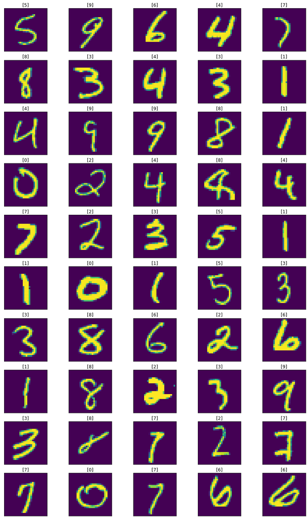

```python
w=20
h=20
fig=plt.figure(figsize=(15, 25))
columns = 5
rows = 10
for i in range(1, columns*rows +1):
    x = Input_Features[i]
    img = x.reshape(28,28)
    fig.add_subplot(rows, columns, i)
    plt.imshow(img)
    plt.title(Output_Labels[i],color="black")
    plt.imshow(img)
    plt.xticks([]),  plt.yticks([])
```

## Spit Dataset

```python
X_train, X_test, y_train, y_test = train_test_split(Input_Features, Output_Labels,
                                                    test_size=0.2, random_state=1, shuffle=True)
```

# Question 4: ( Part 1 )

```python
k_values=[1,2,3,4,5,6,7,8,9,10]
train_scores=[]
test_scores=[]
train_error=[]
test_error=[]

for k in k_values:
    model=DecisionTreeClassifier(max_depth=k)
    model.fit(X_train,y_train)

    train_score=model.score(X_train,y_train)
    test_score=model.score(X_test,y_test)

    train_scores.append(train_score)
    test_scores.append(test_score)

    train_error.append(1-train_score)
    test_error.append(1-test_score)
```

# Question 4: ( Part 2 )

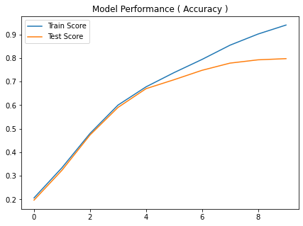

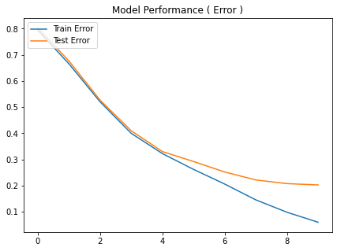

```python
plt.figure()
fig = plt.gcf()
fig.set_size_inches(7, 5)
plt.plot(train_scores)
plt.plot(test_scores)
plt.legend(['Train Score','Test Score'], loc='upper left')
plt.title('Model Performance ( Accuracy )')
plt.show()

plt.figure()
fig = plt.gcf()
fig.set_size_inches(7, 5)
plt.plot(train_error)
plt.plot(test_error)
plt.legend(['Train Error','Test Error'], loc='upper left')
plt.title('Model Performance ( Error )')
plt.show()
```

# Question 4: ( Part 3 )

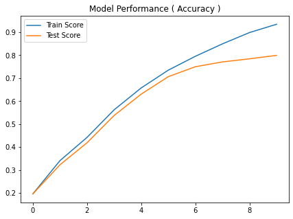

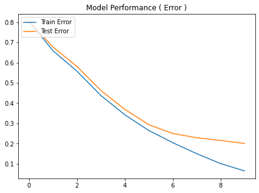

```python
X_train, X_test, y_train, y_test = train_test_split(Input_Features, Output_Labels,test_size=0.2, random_state=100, shuffle=False)
k_values=[1,2,3,4,5,6,7,8,9,10]
train_scores=[]
test_scores=[]
train_error=[]
test_error=[]
for k in k_values:
    model=DecisionTreeClassifier(max_depth=k)
    model.fit(X_train,y_train)
    train_score=model.score(X_train,y_train)
    test_score=model.score(X_test,y_test)
    train_scores.append(train_score)
    test_scores.append(test_score)
    train_error.append(1-train_score)
    test_error.append(1-test_score)
plt.figure()
fig = plt.gcf()
fig.set_size_inches(7, 5)
plt.plot(train_scores)
plt.plot(test_scores)
plt.legend(['Train Score','Test Score'], loc='upper left')
plt.title('Model Performance ( Accuracy )')
plt.show()
plt.figure()
fig = plt.gcf()
fig.set_size_inches(7, 5)
plt.plot(train_error)
plt.plot(test_error)
plt.legend(['Train Error','Test Error'], loc='upper left')
plt.title('Model Performance ( Error )')
plt.show()
```

### We can see in above graphs when we use different random splits of training and test data the performace of our model is also changed.

# Question 4: ( Part 4 )

### How do you explain the difference in the behavior of training and testing error as a function of K?

# Answer:

# Question 4: ( Part 5 )

### Based on your analysis, what is a good setting of K if you were deploy your decision tree classifier to classify handwritten digits?

# Answer:

### Based on our analysis, 10 is a good value of K when we were deploy our decision tree classifier to classify handwritten digits because decision tree classifier is performing best when we use K = 10.

### Its accuracy is maximum and error is minimum on taining and testing data with K = 10.

# ==================== THANKS ===================